# Assortative Mating Model

Dan Conroy-Beam

2023-09-12

## Model Overview

### Purpose

Determine whether assortative mating can emerge from individual mating motivations. Agents will select one another as mates based on a physical attractiveness variable.

Each agent will pursue mates probabilistically and in proportion to mates’ physical attractiveness. The model will then calculate the extent to which agents mate assortatively for attractiveness.

For comparison, the model will also assess assortative mating for randomly formed pairs.

This model is based loosely on Kalick and Hamilton (1986).

### Agents

Each agent will have two randomly assigned features: sex and physical attractiveness. Half of all agents will be male and half will be female.

Agent physical attractiveness values will be drawn from random uniform distributions constrained between 0 and 10.

Agents will also possess a maximum number of dates they will tolerate going on before settling for any mate.

Agent selectivity will gradually decline as they approach their maximum number of dates.

### Life Cycle

1. Date
2. Offer
3. Pair

#### Date

At the start of the life cycle, a random agent will be paired with a random opposite-sex partner. Dating agents’ number of dates will be incremented by one.

#### Offer

Next, each dating agent will decide whether to make a long-term commitment offer to their dating partner. The probability of making an offer will be proportional to their date’s attractiveness, adjusted by the number of dates the agent has gone on.

If an agent has reached their maximum number of dates, they will make an offer to their next date regardless of attractiveness.

#### Pair

Finally, dating agents will pair if both agents mutually make long-term commitment offers to one another.

The life cycle will repeat until all agents are paired

### Analysis

The model will also randomly scramble agent couples and compute the attractiveness correlation for random pairs within model run.

These random choice correlations will be plotted alongside the attractiveness-driven results for comparison.

## Model

### Packages

```r
library(ggplot2)
```

### Parameters

```r
#Population Size#
#Total number of agents to generate
popSize<-100



#Maximum Number of Dates#
#The maximum number of dates agents will go on before settling completely
maxDates<-50



#Model Loops#
#The total number of times to run the mate choice model
modelLoops<-100
```

### Functions

```r
#Agent Generation#
#A function to generate agents
agentGenerate<-function(n,sex){

  #Generate agent physical attractivenesses
  physAtt<-runif(n,0,10)

  #Generate a data structure to store number of dates completed
  numDates<-0

  #Put the agents together
  agents<-data.frame(sex,physAtt,numDates)

  #Output the agents
  return(agents)

}
```

### Life Cycle

```r
#Create a blank dataframe to store model results
results<-data.frame("loop"=rep(1:modelLoops,2),
           "choiceType"=rep(c("Random","Non-Random"),each=modelLoops),
           "r"=NA)

#Loop through modelLoops...
for (l in 1:modelLoops) {

  #Generate the agents
  females <- agentGenerate(popSize / 2, "female")
  males <- agentGenerate(popSize / 2, "male")

  #Create empty vectors to store who is paired with whom
  pairedFemales <- c()
  pairedMales <- c()

  #Repeat as long as some agents remain unpaired...
  while (length(pairedFemales) < nrow(females)) {
    #Date#

    #Create a data structure to store who will go on a date
    fDate <- 1:nrow(females)
    mDate <- 1:nrow(males)

    #Eliminate agents who are already paired
    fDate <- fDate[!(fDate %in% pairedFemales)]
    mDate <- mDate[!(mDate %in% pairedMales)]

    #If more than one option remains, choose one at random
    if (length(fDate) > 1) {
      fDate <- sample(fDate, 1)
    }

    if (length(mDate) > 1) {
      mDate <- sample(mDate, 1)
    }

    #Increment number of dates by 1
    females$numDates[fDate] <- females$numDates[fDate] + 1
    males$numDates[mDate] <- males$numDates[mDate] + 1



    #Offer#

    #Determine how selective agents will be based on number of dates completed so far
    fChoosiness <- (max(c(maxDates,
                          females$numDates[fDate])) -
                      females$numDates[fDate]) / maxDates

    mChoosiness <- (max(c(maxDates,
                          males$numDates[mDate])) -
                      males$numDates[mDate]) / maxDates

    #Set the probability with which agents will make offers of commitment
    fProb <- ((males$physAtt[mDate] ^ 3) / 1000) ^ fChoosiness
    mProb <- ((females$physAtt[fDate] ^ 3) / 1000) ^ mChoosiness

    #Have each agent probabilistically make an offer of commitment
    fOffer <- rbinom(1, 1, fProb)
    mOffer <- rbinom(1, 1, mProb)



    #Pair#

    #If both agents make offers of commitment...
    if (fOffer & mOffer) {
      #...add them to the paired agents vectors
      pairedFemales <- c(pairedFemales, fDate)
      pairedMales <- c(pairedMales, mDate)
    }

  }

  #Compute assortative mating for physical attractiveness given non-random mate choice
  results$r[results$choiceType=="Non-Random" &
              results$loop==l] <- cor(females$physAtt[pairedFemales],
                   males$physAtt[pairedMales])


  results$r[results$choiceType=="Random" &
              results$loop==l] <- cor(females$physAtt[sample(pairedFemales)],
                males$physAtt[sample(pairedMales)])

}
```

### Analysis

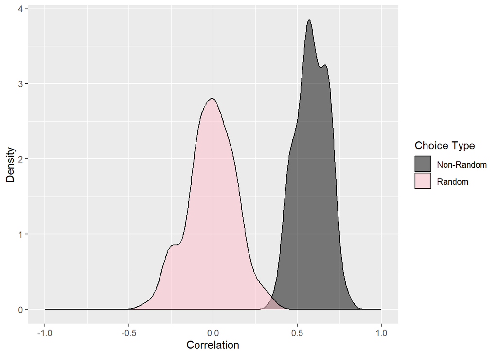

```r
p1<-ggplot(data=results,
           aes(x=r,
               fill=choiceType))+
  labs(x="Correlation",y="Density",fill="Choice Type")+
  geom_density(alpha=.5)+
  scale_fill_manual(labels=c("Non-Random","Random"),
                    values=c("black","pink"))+
  scale_x_continuous(limits=c(-1,1))

p1
```